# Assignment-1

Sai Vignesh Reddy Cholleti

02/11/2022

# 1 The Scatter plot

This R markdown file contains all the code and graphics required for the Assignment-1 of Data Visualization course. Also, the link for this html file can be accessed by [clicking here!](https://htmlpreview.github.io/?https://github.com/VigneshReddy79/STA553-DataViz/blob/main/Assignments/Assignment-1.html)

Downloaded the penguins data set and then uploaded it to my Github data repository.

Found an image of a penguin and uploaded the image to the Github repository.

Read the data set into R from the Github data repository directly.

```r
penguins <- read.csv(file = "https://raw.githubusercontent.com/VigneshReddy79/STA553-DataViz/main/Datasets/w02-penguins.csv")
```

## 1.1 The base Scatter plot between Flipper length and Bill length

The scatter plot between the numerical variables *bill_length_mm* and *flipper_length_mm* from the *penguins* data set with a regression line.

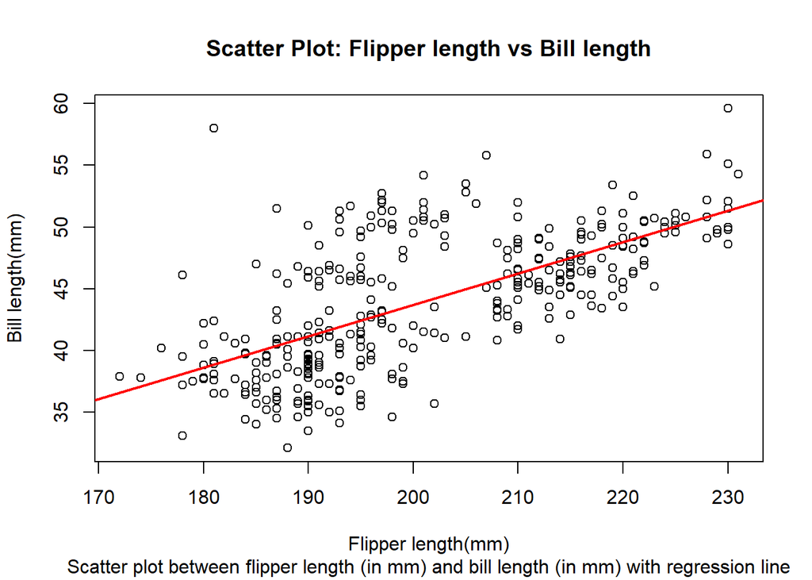

```r
plot( penguins$flipper_length_mm, penguins$bill_length_mm,
     xlab = "Flipper length(mm)",
     ylab = "Bill length(mm)",
     main = "Scatter Plot: Flipper length vs Bill length",
     sub = "Scatter plot between flipper length (in mm) and bill length (in mm) with regression line")
model <- lm(penguins$bill_length_mm ~ penguins$flipper_length_mm, data = penguins)
abline(model, lwd=2, col= "red")
```

## 1.2 The Scatter plot between Flipper length and Bill length with some necessary annotations

The three different species of penguins from the dataset are:

1. Adelie
2. Gentoo
3. Chinstrap

The below image differentiates the three different species in our dataset.

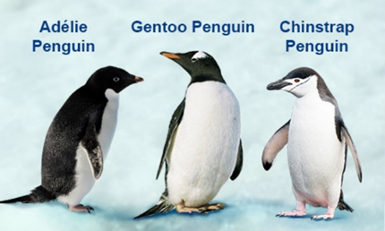

The numerical variables (*bill_length_mm* and *flipper_length_mm*) from the *penguins* data set are used to make a scatter plot and colored the points based on the species.  
Also, modified the scatter plot by following the below instructions:

- The point size should be proportional to body_mass_g of the corresponding penguin.
- insert the image of the penguin you uploaded to the Github repository to the scatter plot.
- add a legend to enhance the readability of your plot.
- make sure the axes of your plot are appropriately labeled. The title of plot should reflect the content in the plot.

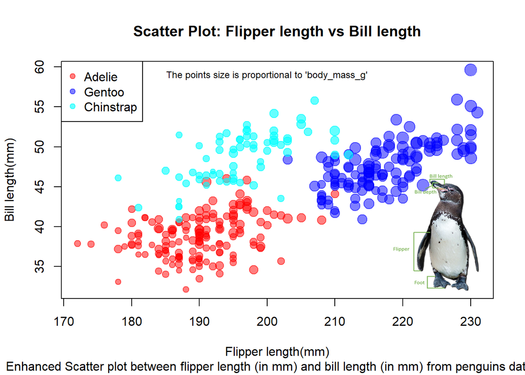

```r
pen.bill <- penguins$bill_length_mm
pen.flipper <- penguins$flipper_length_mm

plot( pen.flipper, pen.bill, type='n',
     xlab = "Flipper length(mm)",
     ylab = "Bill length(mm)",
     main = "Scatter Plot: Flipper length vs Bill length",
     sub = "Enhanced Scatter plot between flipper length (in mm) and bill length (in mm) from penguins dataset")

Adelie.id = which(penguins$species=="Adelie")
Gentoo.id = which(penguins$species=="Gentoo")
Chinstrap.id = which(penguins$species=="Chinstrap")
size.bm <- penguins$body_mass_g

col.code <- c(alpha("red",0.5), alpha("blue",0.5), alpha("cyan",0.6))

img.url <- "http://raw.githubusercontent.com/VigneshReddy79/STA553-DataViz/main/Images/PenguinMeasurements.png"
temp <- tempfile()
download.file(img.url, temp, mode = "wb", cacheOK = FALSE)
img <- readPNG(temp)
raster.img <- as.raster(img)

points(pen.flipper[Adelie.id], pen.bill[Adelie.id], pch = 19, col = col.code[1], cex = size.bm[Adelie.id]/2700)
points(pen.flipper[Gentoo.id], pen.bill[Gentoo.id], pch = 19, col = col.code[2], cex = size.bm[Gentoo.id]/2700)
points(pen.flipper[Chinstrap.id], pen.bill[Chinstrap.id], pch = 19, col = col.code[3], cex = size.bm[Chinstrap.id]/2700)

legend("topleft", c("Adelie","Gentoo","Chinstrap"), col=col.code, pch = 19)
rasterImage(raster.img,218,32,232,47)
text(200, 59, "The points size is proportional to 'body_mass_g'", col = "black", cex = 0.75)
```

Finally, knitted the RMD to HTML format and uploaded the HTML file to my Github repository.